# Investigating the Titanic Disaster

In this project I will use a dataset based on the passengers list of the titanic last trip. This data shows personal details of 891 of the 2208 passengers; things like Name, age and sex, but also their sex, their cabin number, whether they embarked or not, or even if they survived. There are more details to all passengers in here, and it is interesting to find a rich dataset like this one of an event that happened not too long ago in the relative human history, but before the age of technology, where technology could have made a big difference. What I hope to find is if there are any important characteristics to best classify whether a passenger would have likely survive or not.

## Importing our function libraries

```python
import matplotlib.pyplot as plt
import numpy as np
import pandas as pd
import seaborn as sns

sns.set(context='notebook')
```

## Importing Data

pd.read_csv() save us a lot of trouble. It automatically assignes our headers as those the dataframe to be created. It checks if any value in the dataframe can be turned into int64, float64 or long numbers. These representations are analogous to int and float values, but are specific for handling with numpy and pandas. Also, it's 'index_col' arguments help us set a pandasDataFrame's index as the data is loaded into our enviroment.

```python
td = pd.read_csv('titanic_data.csv', index_col = 'PassengerId')
```

### Replacing quantitative missing values

In order to deal with missing values in 'Age', 'SibSp', 'Parch' and 'Fare' I will replace them with the mean values of each respective column. These will be added to the Original dataframe.

```python
### Adding replacing missing values with respective means

td.fillna(td[['Age','SibSp','Parch','Fare']].mean().to_dict(), inplace = True)
```

[output not shown]

### Replacing categorical missing values

Now columns like 'Survived' and 'Pclass', although they contain int data types, are still categorical features. They designate each passenger a label pertaining to a set of categories, and not a value on a spectrum, so it would be wise to simply eliminate these missing values at times of data handling. The 'csbf' and 'cdbf' functions will filter out these rows with missing values for rows of interest.

## Data Exploration and Wranling

The idea here is to quickly review the spead of our variables Let's look at the spread of a few of our variables with numerical values. First they will be visualized with simple bar graphs, and then they will all be reviewed with pandas' describe method.

```python
### Functions to use in simple 1D exploration

def graph_this(variable):
    x = td.groupby(variable).count()['Name'].to_dict()
    plt.bar(xrange(len(x.keys())),x.values())
    plt.xlabel(variable)
    plt.xticks(xrange(len(x.keys())),x.keys())
    plt.ylabel('Number of Passengers')
    plt.show()
```

### Parch

Parch refers to the number of parents and children of said passenger aboard the titanic. Let's see the spread of number of parents and/or children of each passenger aboard.

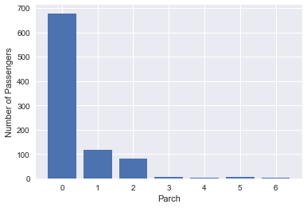

```
count    891.000000
mean       0.381594
std        0.806057
min        0.000000
25%        0.000000
50%        0.000000
75%        0.000000
max        6.000000
Name: Parch, dtype: float64
```

```python
graph_this('Parch')
td.Parch.describe()
```

We can see that not a lot of people were accomponied by their parents and/or children on this trip, at least 75% of passengers in this sample.

### SibSp

The SibSp variable contains the number of sibling and/or number of Spouses of each passenger aboard the Titanic. Let's look at the spread of values.

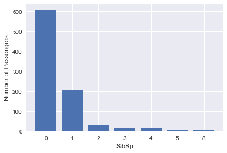

```
count    891.000000
mean       0.523008
std        1.102743
min        0.000000
25%        0.000000
50%        0.000000
75%        1.000000
max        8.000000
Name: SibSp, dtype: float64
```

```python
graph_this('SibSp')
td.SibSp.describe()
```

At least 75% of passengers in this sample were aboard with one or none sibling or spouse during this trip.

### Sex

The 'Sex' variable states the gender of each passenger. Let's compare the amount of women and men aboard at the time of the accident.

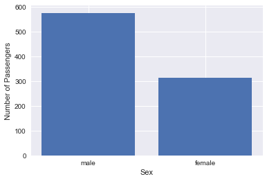

```
count      891
unique       2
top       male
freq       577
Name: Sex, dtype: object
```

```python
graph_this('Sex')
td.Sex.describe()
```

There were almost twice as many males aboard as there were females.

### Survival

The 'Survival' variable states wheter any passenger survived the accident or not. Let's compare the number of survivors to deceased.

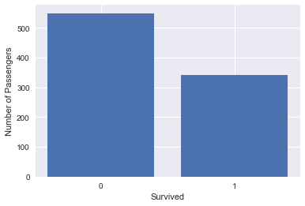

```
count     891
unique      2
top         0
freq      549
Name: Survived, dtype: object
```

```python
### Survival
graph_this('Survived')

# because 'Survived' is a variable denoted with numerical values
# they need to be converted into string values in order to properly
# use the describe method

td.Survived.astype(str).describe()
```

According to our sample's data, there were about 1.5x times casualties as there were survivors.

### Fare

'Fare' is the variable containing the value paid by each passenger for their ticket

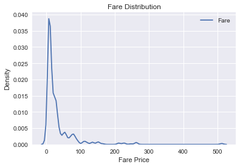

```
count    891.000000
mean      32.204208
std       49.693429
min        0.000000
25%        7.910400
50%       14.454200
75%       31.000000
max      512.329200
Name: Fare, dtype: float64
```

```python
### Fare
sns.kdeplot(td.Fare)\
    .set(title = 'Fare Distribution', xlabel = 'Fare Price', ylabel = 'Density')
plt.show()
td.Fare.describe()
```

This density plot describes the spread of values paid by each passenger. According to the graph and the the presented stats we can see that the vast majority of passengers paid less than a hundred dollars for their ticket.In fact, 75% of passengers paid thirty-one dollars or less for their ticket.

### Age

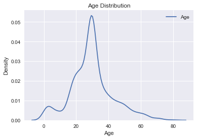

```
count    891.000000
mean      29.699118
std       13.002015
min        0.420000
25%       22.000000
50%       29.699118
75%       35.000000
max       80.000000
Name: Age, dtype: float64
```

```python
### Age

# instead of using the 'graph_this' function, new code will be used
# to properly graph the 'Age variable and it's axes.

# x = td.groupby('Age').count()['Name'].to_dict()
# plt.bar(x.keys(),x.values())

sns.kdeplot(td.Age)\
    .set(title = 'Age Distribution', xlabel = 'Age', ylabel = 'Density')
plt.show()


td.Age.describe()
```

In the age group we can see that our average has filled out several values, making the age distribution disproportionate. Because if this we will reset all spaces in the 'Age' column back to Nans in order to allow our graphing function below to filter these values out

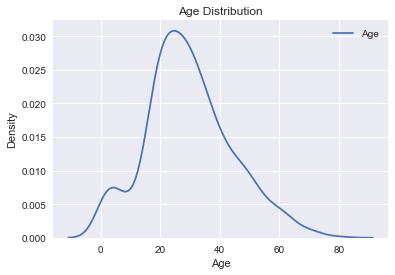

```
count    714.000000
mean      29.699118
std       14.526497
min        0.420000
25%       20.125000
50%       28.000000
75%       38.000000
max       80.000000
Name: Age, dtype: float64
```

```python
# Replacing Age mean values with np.nans
td.Age.replace(to_replace = 29.69911764705882, value = np.nan, inplace = True)

### Age re-evaluated
sns.kdeplot(td.Age.dropna())\
    .set(title = 'Age Distribution', xlabel = 'Age', ylabel = 'Density')
plt.show()
td.Age.describe()
```

Here, a right-tailed distributin is visible. We also know now that 75% of our passengers in this sample were 38 years of age or younger.

## Survivors vs. Deceased (2D analysis)

Let's look for major sources of variance that may explain any major differences between the survivors and deceased. I believe that a major factor in differentiating survivors from deceased was, perhaps traveling class. Traveling class divided the space each passenger mainly roamed; 3rd class inhabiting the lower-center of the cruise, and the other, higher classes expanding outwards towards the top-deck.

### Grouping passengers by "Survived" feature

Now the 'Survived' list decribes a surviving passenger with a 1 and a deceased passenger with a 0, let's look at how many there are of each, and if there are other values that should not be here.

```python
td.groupby(['Survived'])['Pclass'].count()
```

```
Survived
0    549
1    342
Name: Pclass, dtype: int64
```

Now we know that out of 891 original passengers only 342 survived.

```python
s = td.groupby(['Survived']).get_group(1)
d = td.groupby(['Survived']).get_group(0)
```

Let's define a few function to use later on in this work:

```python
### Counting Survivors by feature

def csbf(feature):
    x = s[pd.notnull(s[feature])]\
        .groupby([feature])['Survived'].count().to_dict()
    print 'survivors by %s =' % (feature),x
    return x


### Counting deceased by feature

def cdbf(feature):
    x = d[pd.notnull(d[feature])]\
        .groupby([feature])['Survived'].count().to_dict()

    print 'deceased by %s =' % (feature),x
    return x


### Calculating probability of survival by feature group

def survival_prob_by_feature_group(feature, d1, d2):

    print 'percent of survivors by %s: \n' % (feature)

    for i in d1:
        # Here we calculate and print to console the percentage of survivor
        # per feature group
        print '\t'+str(i)+' class:',\
        str(d1[i]/float(d1[i]+d2[i])*100)+'%'


### Graph percentage-categorical data

def graph_pcat_data(a, title, column_name):

    a = a.groupby([column_name])['Survived'].count().to_dict()
    b = td.groupby([column_name])['Survived'].count().to_dict()

    # c will be a dictionary containing our feature's classes as keys, and their
    # respective percentage values, as values.
    c = {i:(a[i]/float(b[i])) for i in a.keys()}

    #matplotlib will help us plot our data
    plt.bar(range(len(c)), c.values())
    plt.xlabel(column_name)
    plt.ylabel('percent (%)')
    plt.xticks(range(len(c)),c.keys())
    plt.title(title)
    plt.show()

### function for new Adult column

def if_adult(age):
    if age >= 18:
        return 'adult'
    elif age < 18:
        return 'minor'
```

### Is there a noticeable difference between different passenger's travelling class' rate of survival?

```python
### Counting survivors and deceased by Pclass

sbc, dbc = csbf('Pclass'), cdbf('Pclass')
```

```
survivors by Pclass = {1: 136, 2: 87, 3: 119}
deceased by Pclass = {1: 80, 2: 97, 3: 372}
```

We know that there were more than 3 times the amount of 3rd-class passengers who perished in the accident, let's compare probabilities of death according to class

```python
### Calculating probability of survival according to Class of passenger

survival_prob_by_feature_group('Pclass', sbc, dbc)
```

```
percent of survivors by Pclass:

	1 class: 62.962962963%
	2 class: 47.2826086957%
	3 class: 24.2362525458%
```

It seems that 1st class passengers were almost 3 times likely to survive than 3rd class passengers. Another clue of this may be found in the next graph.

#### Graph A

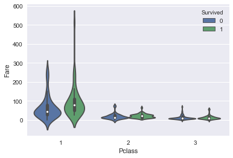

```python
sns.violinplot(x = 'Pclass', y = 'Fare', hue='Survived', data = td)
plt.show()
```

In this plot we are trying to find the disproportions between deceased and survivors according to class, but also according to the fare paid by passengers. 1st class passengers had the greatest variation in paid fare prices, but from the images above one can observe how those in 1st class who survived had paid a relatively higher fare price than their deceased counter parts. Where as survivors and deceased in second (and third class) shared a more similar spectrum in fare price with each other.

## Is there a noticeable difference between male and female rate of survival?

```python
### Counting survivors and deceased by sex

sbs,dbs = csbf('Sex'), cdbf('Sex')
```

```
survivors by Sex = {'male': 109, 'female': 233}
deceased by Sex = {'male': 468, 'female': 81}
```

```python
### Calculating probability of survival according to sex of passenger

survival_prob_by_feature_group('Sex', sbs, dbs)
```

```
percent of survivors by Sex:

	male class: 18.8908145581%
	female class: 74.2038216561%
```

According to our data, females had about a 4x higher rate of survival as did males.

#### Graph B

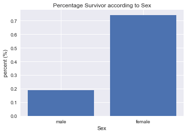

```python
## Now we will graph the rate of survival according to sex

graph_pcat_data(s, 'Percentage Survivor according to Sex', 'Sex')
```

## Is there a noticeable difference in rate of survival between those below and above 18 years of age?

Let's look at the rate of survival according to age. To do this we first have to group survivors into one of two categories: adult or minor. To do so we can make a new column, called adult on our original dataframe. This column will classify a passenger as adult if they are 18 or older, and will be denominated with the keyword 'adult' in the column. If younger than 18 the passenger will be classified as a minor, and denominated with the keyword 'minor' in the column. Then in order to to be able to use out s and d dataframe they should be redefined containing this new columns.

```python
### Let's add the Adult column onto our original dataframe

td['Adult Status'] = td.Age.apply(if_adult)

### Let's redifne our s and d dataframes to include our new Adult Status column

s = td.groupby(['Survived']).get_group(1)
d = td.groupby(['Survived']).get_group(0)
```

```python
### Counting survivors and deceased by Adult status

sbas,dbas = csbf('Adult Status'), cdbf('Adult Status')
```

```
survivors by Adult Status = {'adult': 229, 'minor': 61}
deceased by Adult Status = {'adult': 372, 'minor': 52}
```

```python
survival_prob_by_feature_group('Adult Status', sbas, dbas)
```

```
percent of survivors by Adult Status:

	adult class: 38.1031613977%
	minor class: 53.982300885%
```

#### Graph C

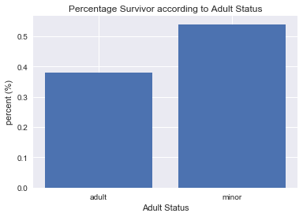

```python
graph_pcat_data(s, 'Percentage Survivor according to Adult Status', 'Adult Status')
```

Adults and minors seem to have survived at different rates. We can also distinguish this in the next graph:

#### Graph D

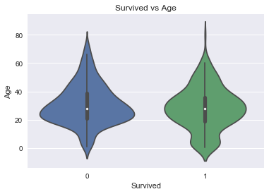

```python
sns.violinplot(x='Survived', y='Age', data = td)\
    .set_title('Survived vs Age')
plt.show()
```

At the left plot we can see how the amount of deceased spikes at somewhere close to 20 years of age. On the opposite side, we can see how the distribution of survivors is ample at the younger side of the spectrum. This further implies a negtive correlation between age and rate of survival.

# Report

In this project I was looking for a characteristic described in the data that best predicted probability of survival per each passenger. I hypothesized that passenger class would be very important in this task since class would best describe the areas where each passenger inhabit the most. For example a first class passenger might have spent most of their time in areas closest to the life raft, atop the deck, even at the time of the accident. From the data on these passengeres we can see that those in 1st class had about a 3x higher rate of survial as those in 3rd class.

Then I looked at the survival rates of passenger separated by sex. It seems as females passengers had a close to 4x times higher rate of survival as males did. This should come as to no surprise; we've all heard the phrase "Women and children first!" somewhere, which led me to believe that another important factor might have also been age.

However, like all data, this set is in no way perfect. There were 2,208 passengers (and crew) abord the titanic in it's last trip. Given that we only have data for 891 passengers, we should bare in mind that we do not know how this sample data was collected, and if there were any biasses in the process of selection. Furthermore, some future work may include: tracing back relatives on-board for each passenger and analysing whether being part of a family made you more likely to survive.

Some factors limiting my analysis were lack of information; not just lack of passenger in the dataset, but also lack of variable values for those passenger already present in the dataset. Other important factors are lack of variables (features), or information on each passenger; maybe presence of specific medical conditions would serve as better markers in calculating rates of survivals.

## Resources:

Pandas' Documentation - http://pandas.pydata.org/pandas-docs/stable/

Numpy's Documentation - https://docs.scipy.org/doc/

Seaborn's Documentation - https://seaborn.pydata.org/api.html#api-ref